# L15b: Using the predict function to add a regression line

23 April 2020

# 1 Follow directly from L15

We start where L15 left off and instead of using the `abline()` function to add a regression line, we will use the `predict()` function. Although overkill for this example, learning to use `predict()` is important when tyring to visualise more complex models where for example curvature is apparent, or where there are several explanatory variables, some of which will neeed to be averaged out to visualise the effects of the remaining ones. Future examples will illustrate these use-cases.

Housekeeping

```r
rm(list=ls()) # remove everything currently held in the R memory
```

# 2 Enter or read in your data from a file

Read in data from our CSV (comma separated value) file

If you need any help for import of the data, take a look at Lesson 3 course material.

Remember that the data file should be in your working directory before you import the file to R.

```r
seed_data <- read.csv("grazing.csv", header=TRUE, stringsAsFactors = FALSE)
```

# 3 Plot and explore your data

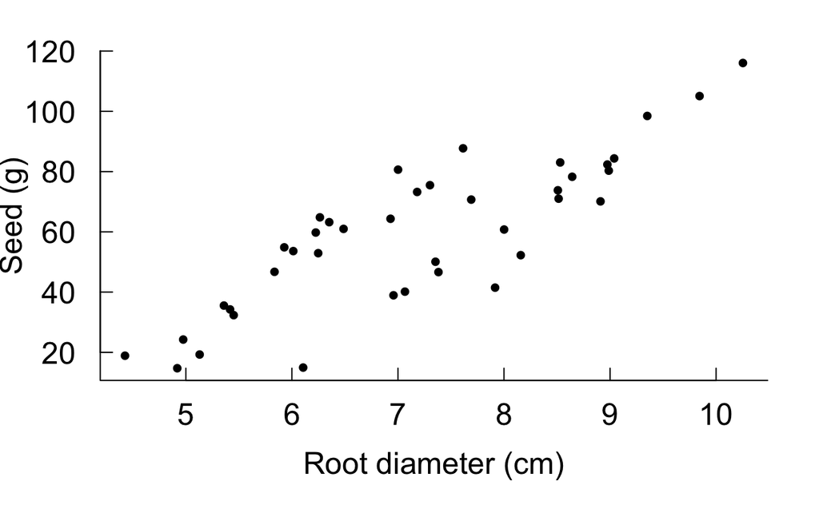

```r
plot(Seed ~ Root, data = seed_data,
     type = "p", xlab = "Root diameter (cm)", ylab ="Seed (g)", pch = 20 ,
        cex.lab = 1.5, cex.axis = 1.5, cex = 1.2,
        bty = "L", las = 1, tcl = 0.5 ) # type = p - this p is for points
```

# 4 Analyse your data

We want to see how root size influences seed size.

```r
 # model 1 will store information on linear model where Y axis variable is Seed and X axis variable is
model1 <- glm(Seed ~ Root, data = seed_data)

# and we can get a more detailed summary of the output
summary(model1)
```

```
Call:
glm(formula = Seed ~ Root, data = seed_data)

Deviance Residuals:
     Min        1Q    Median        3Q       Max
-29.3844  -10.4447   -0.7574   10.7606   23.7556

Coefficients:
            Estimate Std. Error t value Pr(>|t|)
(Intercept)  -41.286     10.723  -3.850 0.000439 ***
Root          14.022      1.463   9.584  1.1e-11 ***
---
Signif. codes:  0 ‘***’ 0.001 ‘**’ 0.01 ‘*’ 0.05 ‘.’ 0.1 ‘ ’ 1

(Dispersion parameter for gaussian family taken to be 182.8641)

    Null deviance: 23743.8  on 39  degrees of freedom
Residual deviance:  6948.8  on 38  degrees of freedom
AIC: 325.81

Number of Fisher Scoring iterations: 2
```

# 5 Create a new dataset on which to predict our model

The object `model1` contains everything needed to make predictions of the response variable based on values provided for the explanatory variables, since it contains the model formula and also the estimated coefficients (including their uncertainty should we want to visualise that too). The first step is to create a new `data.frame` object with the same column names as the explanatory variables used in the model formula.

For this simple example, we only need to predict our response variable at the two end points of the line we want to add, since two points is all that is needed to draw a straight line. In this exmample, we will esimate our response variable $Seed$ at $Root = [5, 10]$.

```r
# createa  new data.frame object, with Root values 5 and 10
new_seed_data <- data.frame(Root = c(5, 10))
```

We can now pass our `new_data` object along with `model1` to the `predict()` function and it will return the corresponding esimated values for the response variable $Seed$. It it useful to bundle this fitted value into the `new_data` object, since that way we have a tidy object that contains everything we need to plot our fitted line. Again, to keep it the same format as the actual data, I am going to call it by the same column names.

```r
# make a column called Seed in our new_data object corresponding to the
# esimated values at the corresponding Root values.
new_seed_data$Seed <- predict(model1, newdata = new_seed_data)

# print it to screen
print(new_seed_data)
```

| Root | Seed |
| --- | --- |
| 5 | 28.82564 |
| 10 | 98.93741 |

```r
NA
```

# 6 Plot the predicted data

With this in hand, we can plot our data again, and add these esimates as a line on our figure using syntax identical to how we are used to plotting data.

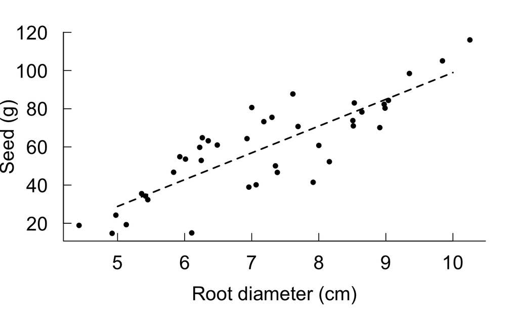

```r
# plot our data again
plot(Seed ~ Root, data = seed_data,
     type = "p", xlab = "Root diameter (cm)", ylab ="Seed (g)", pch = 20 ,
        cex.lab = 1.5, cex.axis = 1.5, cex = 1.2,
        bty = "L", las = 1, tcl = 0.5 )

# add the predicted line
lines(Seed ~ Root, data = new_seed_data,
     col = "black", lty = 2, lwd = 2)
```

## 6.1 Add a confidence interval for the line

Using `predict()` we can also ask it to return confidence intervals for the corresponding estimates. Again, we will make a prediction, and add it on to the `new_data` object; however, note here that we already have a column called `Seed` so we need to be a little careful. Also, since the confidence intervals are curves, we will need more than two points at which to esimated them so will create a sequence of values corresponding to the explanatory variable (x-axis) which in this example is called `Root`. Finally, we need to care as we fitted a model here with `glm()` and the default `predict.glm` doesn’t do confidence intervals, so we need to force it to call `predict.lm()` instead.

```r
# create a new object for now with the expected and upper and lower
# confidence intervals for each value. Here I differentiate this
# new object "new_seed_data_2"
new_seed_data_2 <- data.frame(Root = seq(from = 4, to = 11, by = 0.1))

# calculate the predictions and but them in a separate object first
# NB using predict.lm()
predicted_seed <- predict.lm(model1, newdata = new_seed_data_2,
                             interval = "confidence")

# note the names of the columns
head(predicted_seed)
```

```
       fit       lwr      upr
1 14.80329  4.434005 25.17257
2 16.20553  6.104647 26.30640
3 17.60776  7.773693 27.44183
4 19.01000  9.441009 28.57898
5 20.41223 11.106448 29.71801
6 21.81447 12.769845 30.85909
```

```r
# now we can put this onto the end of the new_seed_data_2 object
# to keep it all in one place by binding the columns using cbind()
new_seed_data_2 <- cbind(new_seed_data_2, predicted_seed)

# plot our data again

par(mfrow = c(1,1)) # set the panel back to 1x1 figure

plot(Seed ~ Root, data = seed_data,
     type = "p", xlab = "Root diameter (cm)", ylab ="Seed (g)", pch = 20 ,
        cex.lab = 1.5, cex.axis = 1.5, cex = 1.2,
        bty = "L", las = 1, tcl = 0.5 )

# and now add our lines

# add the expected value first
lines(fit ~ Root, data = new_seed_data_2,
      col = "black", lty = 1, lwd = 2)
```

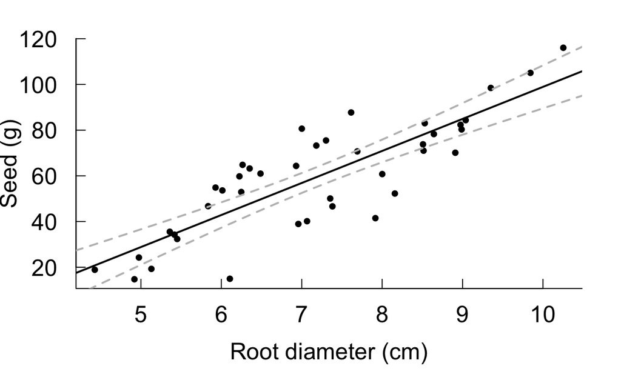

```r
# then the lower estimate
lines(lwr ~ Root, data = new_seed_data_2,
      col = "grey", lty = 2, lwd = 2)

# then upper in the same style
lines(upr ~ Root, data = new_seed_data_2,
      col = "grey", lty = 2, lwd = 2)
```

```r
NA
NA
NA
```